# Data Analyst Job Market Report

Tiogouo Tezemene Kevine

28-05-2025

## Introduction

This report presents an analysis of Data Analyst job postings, with aim to explore the relationship between years of experience and salary, as well as how proficiency in different data languages affects salary distributions.

- **Total job postings analyzed:** 400
- **Average median salary estimate:** $ 71,794
- **Programming language requirements:** (R, Python, both, or neither)

## Years of Experience Analysis

Figure 1 shows a slight positive relationship (0.05) between minimum years of experience required and the median salary estimate, with higher experience associated with higher compensation. However, salaries vary widely, especially for jobs requiring 0 to 5 years of experience—suggesting that factors beyond experience, play a significant role in salary levels. While the trend is upward, the widening confidence interval and limited data for jobs requiring over 10 years of experience indicate that conclusions in that range should be made cautiously due to sample size limitations.

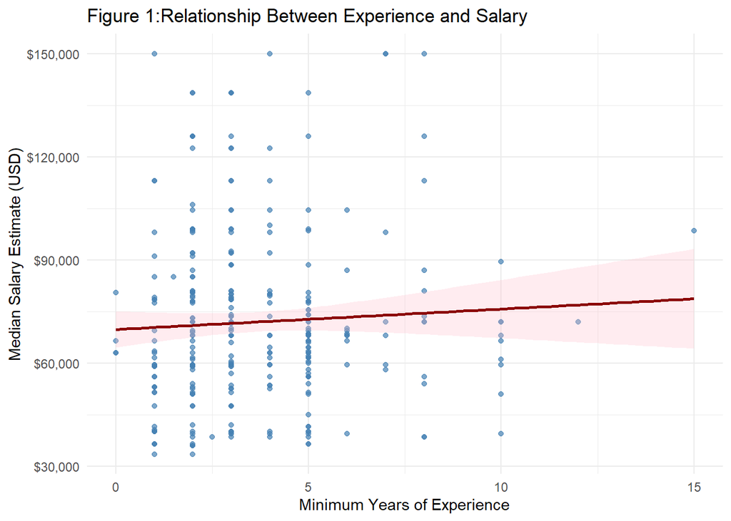

## Programming Language Analysis

Figure 2 compares salary distributions across different programming language requirements for jobs. Jobs requiring both R and Python offer the highest median salaries and show a wider salary range. Followed by Roles with no programming language requirement or requiring Python only. Jobs requiring only R or either R or Python tend to offer lower median salaries. However, its important to note that our small sample size does not allow us to make any conclusion.

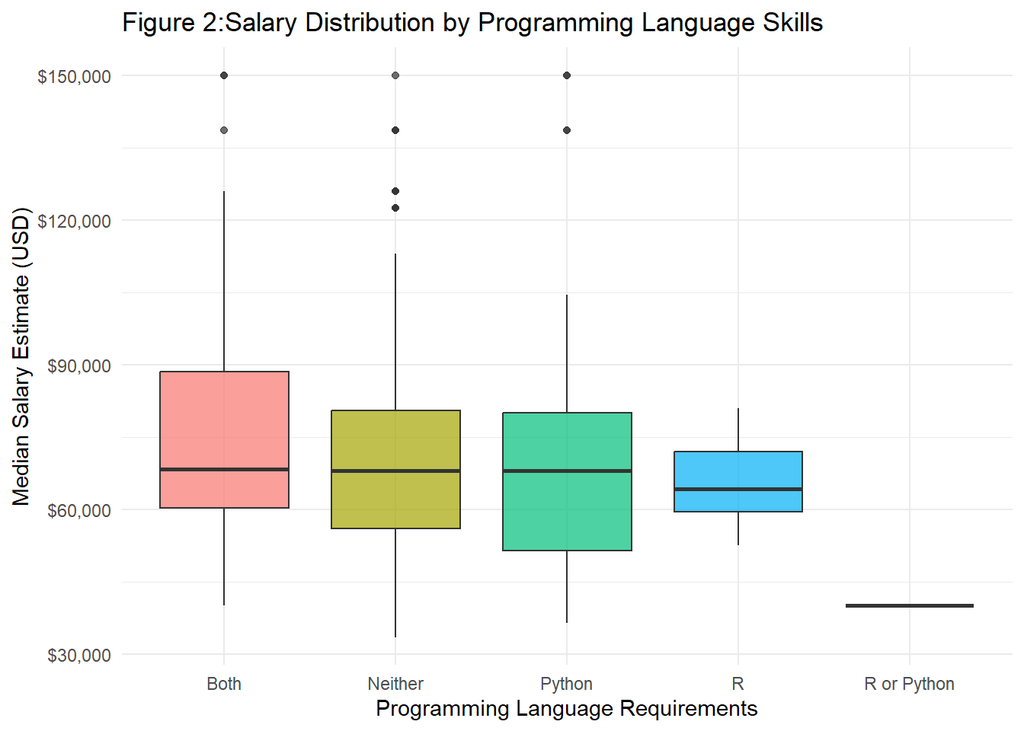

## Reflection

Using Cursor as an AI-powered tool to streamline this analysis was an exciting experience. Its ability to generate reports with minimal manual coding highlights the transformative impact of AI on data analysis workflows. However, I did encounter a challenge—my initial prompt was blocked, and I had to close the app and wait until the next day to proceed. Fortunately, it worked smoothly afterward, and I was able to complete my analysis successfully.